# Tree from Open Tree

2023-04-20

Insects- 1 million named species Mammals - 5k named species Flowering plants: 200k named species

### Read a newick tree from the Open Tree of Life’

```r
tree <- read.tree(file = "../data raw/Weigmann_2009.tre")
```

Now plot the tree:

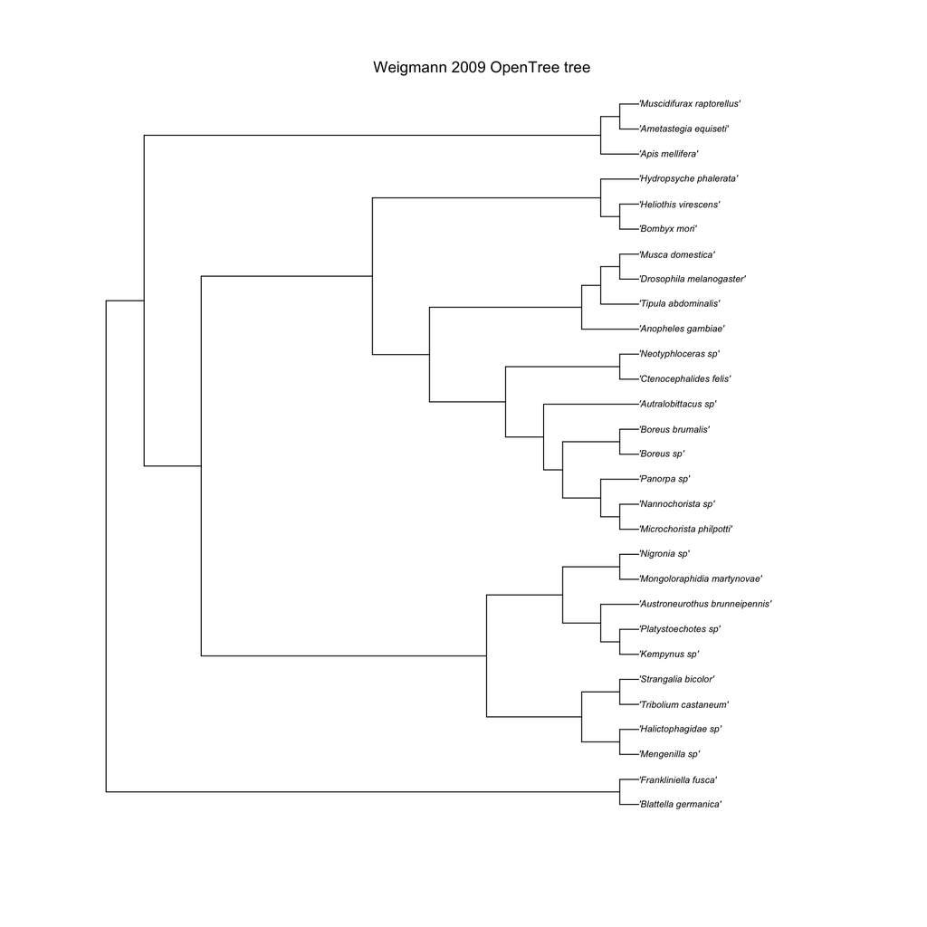

```r
plot(tree, cex = 0.6)
mtext(text = "Weigmann 2009 OpenTree tree")
```

#We can also use a url of a tree to read a tree into R. We will provide the URL in the argument `file =` In this case, we do nor have to keep a copy of the file, we can just download it directly The url is “http://ape-package.ird.fr/APER/APER2/primfive.tre”:

```r
?read.tree
small_tree <- read.tree(file = "http://ape-package.ird.fr/APER/APER2/primfive.tre")
```

### Getting a tree for your species from the Open Tree of Life

The Open Tree of Like has tools that allow to match the names of a group or species to there unfied taxonomy so that we can look for information on their databases.

If we are doing this in R, we are using the `tnrs_match_names()` from the package `rotl`“; tnrs stands for taxonomic name resolution service:

```r
tnrs <- tnrs_match_names(names = "amphibians")
class(tnrs)
```

```
## [1] "match_names" "data.frame"
```

What is the difference we have in `search_string` and `unique_name`

One is the search string and the other is the scientific taxonomic name from the Open Tree of Life unified Taxonomy (OTT).

We can use the unique number identifier from OTT to get information for that taxon.

To get a tree we can use the function `tol_subtree()`

```r
tol_subtree(ott_id = tnrs$ott_id)
```

```
##
Progress [---------------------------------] 0/189 (  0) ?s
Progress [==============================] 189/189 (100)  0s
```

[output not shown]

[output cut: 10 more lines]

[output not shown]

```
##
## Phylogenetic tree with 10020 tips and 4669 internal nodes.
##
## Tip labels:
##   Odorrana_geminata_ott114, Odorrana_chapaensis_ott214633, Odorrana_grahami_ott43280, Odorrana_margaretae_ott440550, Odorrana_kuangwuensis_ott3618367, Odorrana_junlianensis_ott656728, ...
## Node labels:
##   Amphibia ott544595, Batrachia ott471197, Anura ott991547, , , , ...
##
## Unrooted; no branch lengths.
```

Homework: Try to get OTT id for my organism